# Assignment -FMST

#### importing the libraries

```python
import pandas as pd
import numpy as np
from sklearn import metrics
import matplotlib.pyplot as plt
%matplotlib inline
import seaborn as sns
from sklearn.model_selection import train_test_split
from sklearn.tree import DecisionTreeClassifier
#from sklearn.feature_extraction.text import CountVectorizer  #DT does not take strings as input for the model fit step....
from IPython.display import Image
#import pydotplus as pydot
from sklearn.model_selection import train_test_split
from sklearn.svm import SVC
from sklearn import tree
from os import system
```

### Importing Data

```python
df = pd.read_csv('concrete.csv')
df.head()
```

|  | cement | slag | ash | water | superplastic | coarseagg | fineagg | age | strength |
| --- | --- | --- | --- | --- | --- | --- | --- | --- | --- |
| 0 | 141.3 | 212.0 | 0.0 | 203.5 | 0.0 | 971.8 | 748.5 | 28 | 29.89 |
| 1 | 168.9 | 42.2 | 124.3 | 158.3 | 10.8 | 1080.8 | 796.2 | 14 | 23.51 |
| 2 | 250.0 | 0.0 | 95.7 | 187.4 | 5.5 | 956.9 | 861.2 | 28 | 29.22 |
| 3 | 266.0 | 114.0 | 0.0 | 228.0 | 0.0 | 932.0 | 670.0 | 28 | 45.85 |
| 4 | 154.8 | 183.4 | 0.0 | 193.3 | 9.1 | 1047.4 | 696.7 | 28 | 18.29 |

```python
df.info()
```

```
<class 'pandas.core.frame.DataFrame'>
RangeIndex: 1030 entries, 0 to 1029
Data columns (total 9 columns):
cement          1030 non-null float64
slag            1030 non-null float64
ash             1030 non-null float64
water           1030 non-null float64
superplastic    1030 non-null float64
coarseagg       1030 non-null float64
fineagg         1030 non-null float64
age             1030 non-null int64
strength        1030 non-null float64
dtypes: float64(8), int64(1)
memory usage: 72.5 KB
```

There are about 8 attributes with float values and 1 integer value which is age

```python
df.shape
```

```
(1030, 9)
```

### EDA

We can see there are 1030 rows and total 9 columns

```python
df.describe().T
```

|  | count | mean | std | min | 25% | 50% | 75% | max |
| --- | --- | --- | --- | --- | --- | --- | --- | --- |
| cement | 1030.0 | 281.167864 | 104.506364 | 102.00 | 192.375 | 272.900 | 350.000 | 540.0 |
| slag | 1030.0 | 73.895825 | 86.279342 | 0.00 | 0.000 | 22.000 | 142.950 | 359.4 |
| ash | 1030.0 | 54.188350 | 63.997004 | 0.00 | 0.000 | 0.000 | 118.300 | 200.1 |
| water | 1030.0 | 181.567282 | 21.354219 | 121.80 | 164.900 | 185.000 | 192.000 | 247.0 |
| superplastic | 1030.0 | 6.204660 | 5.973841 | 0.00 | 0.000 | 6.400 | 10.200 | 32.2 |
| coarseagg | 1030.0 | 972.918932 | 77.753954 | 801.00 | 932.000 | 968.000 | 1029.400 | 1145.0 |
| fineagg | 1030.0 | 773.580485 | 80.175980 | 594.00 | 730.950 | 779.500 | 824.000 | 992.6 |
| age | 1030.0 | 45.662136 | 63.169912 | 1.00 | 7.000 | 28.000 | 56.000 | 365.0 |
| strength | 1030.0 | 35.817961 | 16.705742 | 2.33 | 23.710 | 34.445 | 46.135 | 82.6 |

Looks like there is a differenc in values in terms of range.

- The superplastic range is very low compared to others.
- The column age too seems to hav a different range.

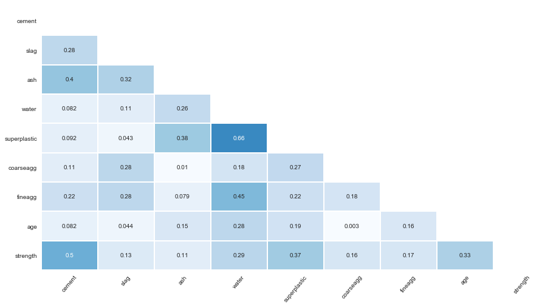

```python
corr = abs(df.corr()) # correlation matrix
lower_triangle = np.tril(corr, k = -1)  # select only the lower triangle of the correlation matrix
mask = lower_triangle == 0  # to mask the upper triangle in the following heatmap

plt.figure(figsize = (15,8))  # setting the figure size
sns.set_style(style = 'white')  # Setting it to white so that we do not see the grid lines
sns.heatmap(lower_triangle, center=0.5, cmap= 'Blues', annot= True, xticklabels = corr.index, yticklabels = corr.columns,
            cbar= False, linewidths= 1, mask = mask)   # Da Heatmap
plt.xticks(rotation = 50)   # Aesthetic purposes
plt.yticks(rotation = 0)   # Aesthetic purposes
plt.show()
```

The correlation triangle shows that there is'nt much correlation apart from

- superplastic and water
- strength and cement

## Bivariate analysis

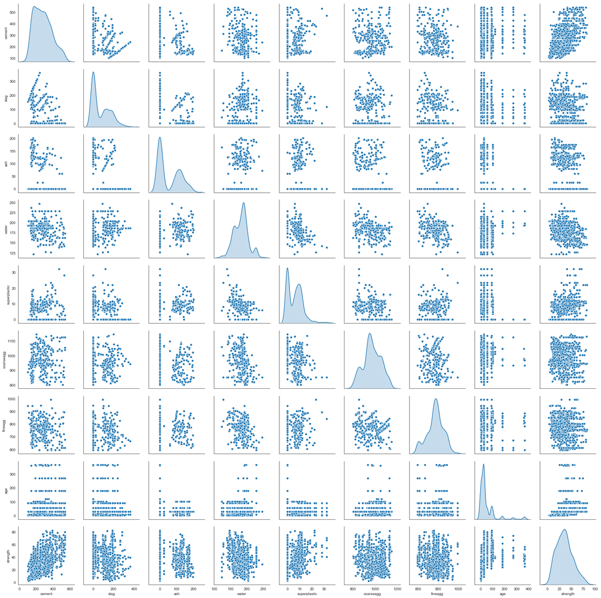

```python
sns.pairplot(df , diag_kind = 'kde')
```

The pairplot allows us to see if there is any correlation between any two variables or with the result.

## Checking for outliers.

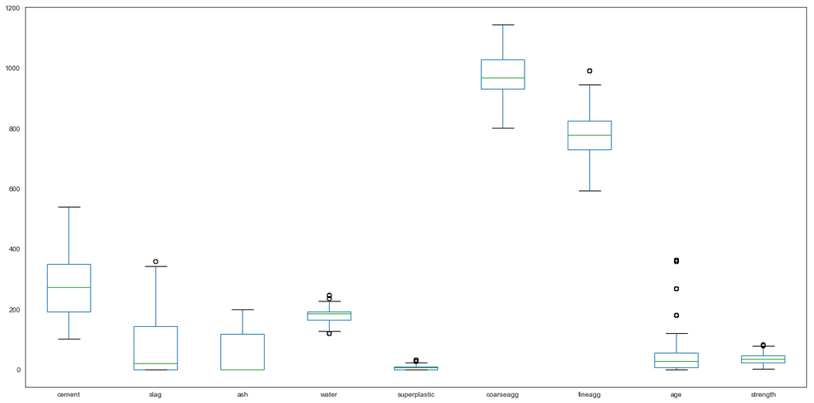

```python
df.plot(kind='box', figsize=(20,10))
plt.show()
```

We can see ther are a few outliers here in water, superplastic , age, fineagg, strenght.

- We can also see the disparity in the range of values of different columns.
- The courseagg an fineagg have very high values.

## Missing Values

```python
def missing_check(df):
    total = df.isnull().sum().sort_values(ascending=False)   # total number of null values
    percent = (df.isnull().sum()/df.isnull().count()).sort_values(ascending=False)  # percentage of values that are null
    missing_data = pd.concat([total, percent], axis=1, keys=['Total', 'Percent'])  # putting the above two together
    return missing_data # return the dataframe
missing_check(df)
```

|  | Total | Percent |
| --- | --- | --- |
| strength | 0 | 0.0 |
| age | 0 | 0.0 |
| fineagg | 0 | 0.0 |
| coarseagg | 0 | 0.0 |
| superplastic | 0 | 0.0 |
| water | 0 | 0.0 |
| ash | 0 | 0.0 |
| slag | 0 | 0.0 |
| cement | 0 | 0.0 |

```python
df.isnull().sum().sum()
```

```
0
```

As we can see there is no null values

## Univariate Analysis

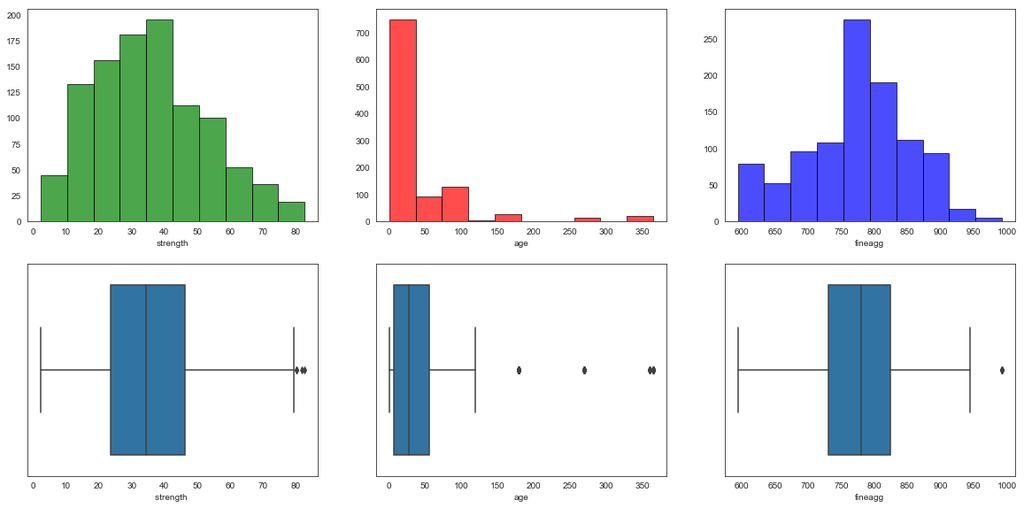

```python
plt.figure(figsize= (20,15))
plt.subplot(3,3,1)
plt.hist(df['strength'], color='green', edgecolor = 'black', alpha = 0.7)
plt.xlabel('strength')

plt.subplot(3,3,2)
plt.hist(df['age'], color='red', edgecolor = 'black', alpha = 0.7)
plt.xlabel('age')

plt.subplot(3,3,3)
plt.hist(df['fineagg'], color='blue', edgecolor = 'black', alpha = 0.7)
plt.xlabel('fineagg')

plt.subplot(3,3,4)
sns.boxplot(x=df['strength'])
plt.xlabel('strength ')

plt.subplot(3,3,5)
sns.boxplot(x=df['age'])
plt.xlabel('age')

plt.subplot(3,3,6)
sns.boxplot(x=df['fineagg'])
plt.xlabel('fineagg')
plt.show()
```

A shown int the graph of age there are a few outliers and strength as well as fineagg.

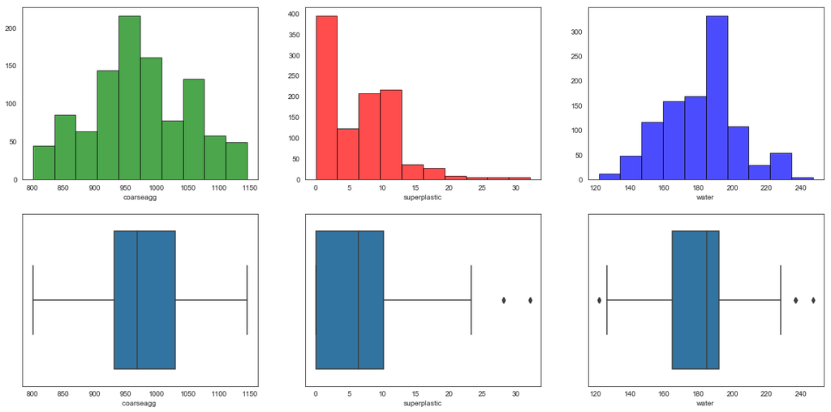

```python
plt.figure(figsize= (20,15))
plt.subplot(3,3,1)
plt.hist(df['coarseagg'], color='green', edgecolor = 'black', alpha = 0.7)
plt.xlabel('coarseagg')

plt.subplot(3,3,2)
plt.hist(df['superplastic'], color='red', edgecolor = 'black', alpha = 0.7)
plt.xlabel('superplastic')


plt.subplot(3,3,3)
plt.hist(df['water'], color='blue', edgecolor = 'black', alpha = 0.7)
plt.xlabel('water')

plt.subplot(3,3,4)
sns.boxplot(x=df['coarseagg'])
plt.xlabel('coarseagg ')

plt.subplot(3,3,5)
sns.boxplot(x=df['superplastic'])
plt.xlabel('superplastic')

plt.subplot(3,3,6)
sns.boxplot(x=df['water'])
plt.xlabel('water')
plt.show()
```

the courseagg does not seem to have any outliers while water and superplastic both have.

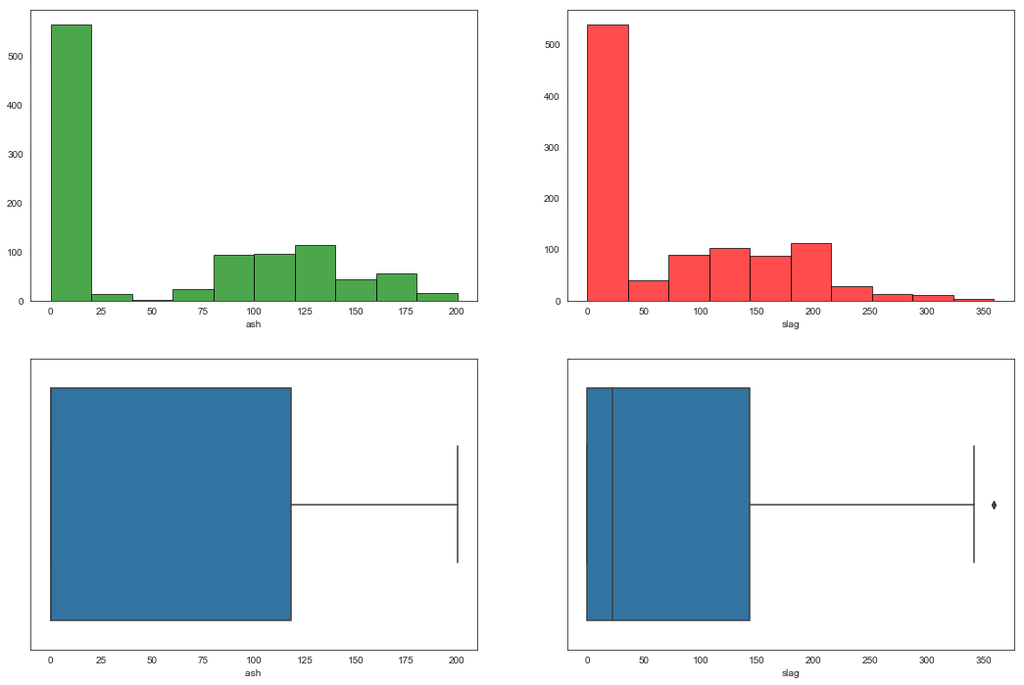

```python
plt.figure(figsize= (18,12))
plt.subplot(2,2,1)
plt.hist(df['ash'], color='green', edgecolor = 'black', alpha = 0.7)
plt.xlabel('ash')

plt.subplot(2,2,2)
plt.hist(df['slag'], color='red', edgecolor = 'black', alpha = 0.7)
plt.xlabel('slag')

plt.subplot(2,2,3)
sns.boxplot(x=df['ash'])
plt.xlabel('ash ')

plt.subplot(2,2,4)
sns.boxplot(x=df['slag'])
plt.xlabel('slag')


plt.show()
```

## Output analysis

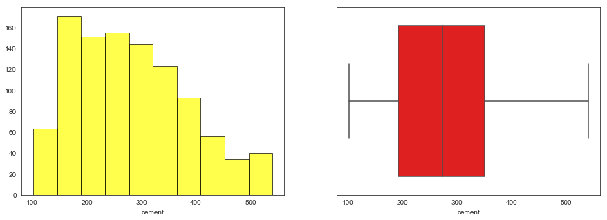

```python
plt.figure(figsize= (15,5))
plt.subplot(1,2,1)
plt.hist(df['cement'], color='yellow', edgecolor = 'black', alpha = 0.7)
plt.xlabel('cement')

plt.subplot(1,2,2)
sns.boxplot(x=df['cement'],color="red")
plt.xlabel('cement')


plt.show()
```

The output seems to normally distributed and there does not seem to be ay outliers.

### Deciding on the outliers

Calculation of inter-quartile range

```python
Q1 = df.quantile(0.25)
Q3 = df.quantile(0.75)
IQR = Q3 - Q1
```

```python
print(((df < (Q1 - 1.5 * IQR)) | (df > (Q3 + 1.5 * IQR))).sum())
print(((df < (Q1 - 1.5 * IQR)) | (df > (Q3 + 1.5 * IQR))).sum().sum())
```

```
cement           0
slag             2
ash              0
water            9
superplastic    10
coarseagg        0
fineagg          5
age             59
strength         4
dtype: int64
89
```

Showing the outliers by column and also total outliers.

```python
mask = (df < (Q1 - 1.5 * IQR)) | (df > (Q3 + 1.5 * IQR))
df[mask] = np.nan
df = df.dropna()
```

I have decided to drop all the outliers since it accounts to about 8% of the data . So that the data is not biased and more accurate

```python
print(((df < (Q1 - 1.5 * IQR)) | (df > (Q3 + 1.5 * IQR))).sum())
print(((df < (Q1 - 1.5 * IQR)) | (df > (Q3 + 1.5 * IQR))).sum().sum())
```

```
cement          0
slag            0
ash             0
water           0
superplastic    0
coarseagg       0
fineagg         0
age             0
strength        0
dtype: int64
0
```

Successfully dropped all the outliers

### Splitting the data into train and test

```python
X = df.drop(columns=['cement'])  # predictors
y = df['cement']
```

Scaling the data as well since we saw earlier that the data was not in the same range

```python
from sklearn.preprocessing import StandardScaler    # to scale the data
from sklearn.model_selection import train_test_split  # to split the data into test and train sets

scaler = StandardScaler()   # creating a scaler object

'''To avoid data leakage, we will fit the scaler object using the train set and then transform the train and test sets using
the fitted Scaler object'''

X_train, X_test, y_train, y_test = train_test_split(X, y,
                                                    random_state = 1,
                                                    )# Stratify y to keep the class proportions consistent

scaler.fit(X_train)  # fitting the scaler object using the train data

X_train_scaled = scaler.transform(X_train)  # transform the train set
X_test_scaled = scaler.transform(X_test)    # transform the test set

'''Because .transform returns nd arrays, assigning them back to the respective dataframes to retain dataframe structure,
but with scaled values'''

X_train.iloc[:,:] = X_train_scaled
X_test.iloc[:,:] = X_test_scaled
```

```python
X_train.shape
```

```
(705, 8)
```

```python
X_train.head()
```

|  | slag | ash | water | superplastic | coarseagg | fineagg | age | strength |
| --- | --- | --- | --- | --- | --- | --- | --- | --- |
| 113 | -0.857639 | -0.913080 | 0.283682 | -1.160552 | -0.106178 | -0.183948 | -0.164054 | -0.210438 |
| 397 | -0.857639 | 0.640220 | 0.811863 | 0.643208 | -0.191048 | -0.946550 | -0.164054 | -0.285347 |
| 23 | 1.578893 | 1.597777 | -0.086045 | -0.240266 | -1.379233 | -0.540181 | -0.164054 | -0.091680 |
| 849 | -0.857639 | -0.913080 | 0.600591 | -1.160552 | 1.051144 | 0.422967 | -1.021033 | -1.153196 |
| 73 | 1.203408 | -0.913080 | -0.498026 | -0.755626 | 0.331032 | 0.680247 | -0.164054 | -0.480232 |

```python
X_test.shape
```

```
(236, 8)
```

```python
y_test.shape
```

```
(236,)
```

The data has been split into 705 rows for training and 236 rows for test.

```python
X_test.head()
```

|  | slag | ash | water | superplastic | coarseagg | fineagg | age | strength |
| --- | --- | --- | --- | --- | --- | --- | --- | --- |
| 658 | -0.857639 | -0.913080 | 0.442136 | -1.160552 | 1.938425 | -2.163020 | -0.164054 | 1.287134 |
| 571 | 1.920243 | -0.913080 | 0.600591 | -1.160552 | -0.499668 | 0.056179 | -0.164054 | -0.069755 |
| 976 | 1.537695 | -0.913080 | 1.207999 | -1.160552 | -0.113894 | -1.925531 | -0.883916 | -0.542961 |
| 214 | 2.002637 | -0.913080 | -0.033227 | 0.864076 | 0.613933 | -1.041546 | -0.164054 | 0.155581 |
| 459 | 1.306990 | 1.320179 | 0.695663 | 0.532773 | -1.217208 | -1.034949 | -0.164054 | -0.354166 |

## Model fitting method

```python
def fit_n_print(model, X_train, X_test, y_train, y_test):  # take the model, and data as inputs
    from sklearn import metrics

    model.fit(X_train, y_train)   # for the model with the train data

    pred = model.predict(X_test)  # make predictions on the test set

    score = round(model.score(X_test, y_test), 3)   # compute accuracy score for test set
 #   f1_score =  round(2*precision*recall/(precision + recall), 3)

    return score# return all the metrics
```

## Model Decision

- Since the outcome is a continous variable then the classification models won't work .
- So I think the linear regression model will be best suited which is simple and we dont need to drop any columns.
- As there aren't too much columns we can opt for the simple models.

## Linear Regression

```python
from sklearn.linear_model import LinearRegression

regression_model = LinearRegression()
OrigScore=fit_n_print(regression_model, X_train, X_test, y_train, y_test)
regression_model.coef_
```

```
array([-87.62856935, -73.57977865, -44.99252991,  -5.06076351,
       -55.96013421, -66.71809598, -15.7720404 ,  31.45009231])
```

```python
OrigScore*100
```

```
88.6
```

### Implementing k-folds to know how the model will perform in production

```python
from sklearn.model_selection import KFold
from sklearn.model_selection import cross_val_score

num_folds = 50
seed = 1
kfold = KFold(n_splits=num_folds, random_state=seed,shuffle=True)
model = LinearRegression()
results = cross_val_score(model, X, y, cv=kfold)
print(results)
print("Accuracy: %.3f%% (%.3f%%)" % (results.mean()*100.0, results.std()*100))
```

```
[0.91200496 0.8469658  0.9112801  0.90912774 0.81236818 0.78460736
 0.88495771 0.95425706 0.86542544 0.88377337 0.90521056 0.87245785
 0.8656232  0.91208063 0.89177174 0.90813767 0.76291493 0.94522082
 0.86036885 0.89879538 0.9266896  0.9482121  0.93781029 0.87068433
 0.85975206 0.85414881 0.9219513  0.83785639 0.86173915 0.91546285
 0.94591453 0.93312869 0.92454975 0.86699523 0.91698786 0.87445573
 0.84093017 0.90150357 0.73761077 0.66387039 0.81436116 0.8480696
 0.93130017 0.88462175 0.84610213 0.9304722  0.89106448 0.83359517
 0.90024718 0.80365896]
Accuracy: 87.622% (5.667%)
```

We can see the model performs with an average score of 87.6 in productipn as well with a standard deviation of 5.667% whcih means the accuracy can vary from 82% to 92% roughly in production. this is a very good score for a model in production.

## Feature Importance

We can check the importance of each column using ridge and lasso models and drop accordingly to improve the model.

```python
from sklearn.linear_model import Ridge
from sklearn.linear_model import Lasso

ridge = Ridge(alpha=.3)
ridge.fit(X_train,y_train)
print ("Ridge model:", (ridge.coef_))
```

```
Ridge model: [-87.48551663 -73.45967542 -44.75085939  -4.99740135 -55.76388206
 -66.51366283 -15.85173322  31.58932982]
```

```python
lasso = Lasso(alpha=0.1)
lasso.fit(X_train,y_train)
print ("Lasso model:", (lasso.coef_))
```

```
Lasso model: [-87.21455372 -73.36456985 -43.99150559  -4.42875908 -55.22258193
 -66.03842792 -15.83968435  31.66287121]
```

We can see the ridge and lasso models also show some coefficient values for the attributes.

- Lets check their score.

```python
RidgeScore =fit_n_print(ridge, X_train_scaled, X_test_scaled, y_train, y_test)
RidgeScore*100
```

```
88.6
```

```python
LassoScore =fit_n_print(lasso, X_train_scaled, X_test_scaled, y_train, y_test)
LassoScore*100
```

```
88.7
```

Both the lasso and ridge give almost similiar score as linear regression models.

## Let us try by adding polynomaila features

```python
from sklearn.preprocessing import PolynomialFeatures
poly = PolynomialFeatures(degree = 4, interaction_only=True)
```

```python
X_poly = poly.fit_transform(X)
X_poly.shape
X_poly_train, X_poly_test, y_poly_train, y_poly_test = train_test_split(X_poly, y, test_size=0.30, random_state=1)
X_poly_train
```

```
array([[1.00000000e+00, 0.00000000e+00, 1.17500000e+02, ...,
        2.82729740e+07, 2.08287895e+07, 2.24249325e+09],
       [1.00000000e+00, 0.00000000e+00, 1.38000000e+02, ...,
        1.00360814e+07, 9.92331648e+06, 7.22597864e+08],
       [1.00000000e+00, 2.38700000e+02, 0.00000000e+00, ...,
        4.74663259e+06, 3.24038933e+06, 5.15273338e+08],
       ...,
       [1.00000000e+00, 1.06300000e+02, 0.00000000e+00, ...,
        2.37343764e+07, 2.47092657e+07, 1.27604638e+09],
       [1.00000000e+00, 0.00000000e+00, 0.00000000e+00, ...,
        0.00000000e+00, 0.00000000e+00, 2.26575776e+08],
       [1.00000000e+00, 9.78000000e+01, 2.45000000e+01, ...,
        7.94250126e+06, 5.85382616e+06, 5.54911360e+08]])
```

```python
regression_model.fit(X_poly_train, y_poly_train)
print(regression_model.coef_)
```

```
[-1.13258848e-02  1.01402335e+02 -2.01343632e+02  1.65629779e+02
 -1.05753820e+03  2.93504298e+01  4.22321699e+01  5.96808062e+02
  5.28887443e+02  2.86119163e-01 -4.62404575e-01 -1.96222452e-01
 -9.21806101e-02 -1.59543814e-01  3.53786735e-01 -8.11186741e-02
  1.05568822e+00  1.33653972e+01  1.91361174e-01  1.53529234e-01
  1.44173891e+00 -1.67753821e+00  3.57940650e+00 -1.49601108e-01
 -2.17496998e-01 -3.20446429e+00 -2.61985197e+00  1.18493114e+00
  7.85274664e-01 -9.70425755e+00  2.71681088e+00 -3.90934866e-02
 -7.11030005e-01 -4.01569087e-01 -9.48262354e-01 -4.34940045e-01
  1.18545246e+00 -1.56988685e-03 -6.47639975e-03 -1.39528054e-04
 -3.28714835e-04  1.01011065e-03  2.04760624e-03  1.28800689e-02
  4.08868360e-04  7.44232957e-04 -4.15789791e-04 -8.39960426e-04
 -1.76751314e-03  2.81283511e-03 -1.97549145e-03 -4.98431335e-02
  1.51349411e-04 -2.69433716e-04 -1.39916409e-05 -6.84276888e-05
  3.92036369e-04 -6.11433027e-03 -3.14076079e-02 -1.04018385e-03
 -8.21739664e-04 -7.63371412e-03  5.77513146e-03 -1.12630123e-02
 -7.31903889e-03 -5.19106790e-02 -4.28632828e-02 -1.43736686e-04
 -6.46039657e-04  8.61307206e-04 -2.04885542e-04  1.80784560e-03
 -6.16832393e-03 -4.40063921e-03 -2.34205811e-03 -5.92502716e-02
  4.64307453e-02  1.96379126e-04  3.71910452e-03  1.97483927e-03
  5.02781738e-03  2.07218287e-03 -3.99785937e-03 -9.45269111e-04
  1.24108297e-02 -2.47651642e-03  1.86687460e-02 -9.70031323e-03
  8.27763221e-02  1.05842444e-03  2.72323666e-04 -3.26710489e-04
 -6.18715022e-04  6.77059960e-06  4.83487596e-07  1.63363143e-06
 -4.52323067e-06 -2.88018262e-06  4.59544816e-06  4.57045016e-07
  9.69952856e-06  4.66805267e-06  1.07501191e-07  4.28144524e-08
 -1.30198593e-06 -3.36396315e-07 -4.97732361e-07 -7.68676122e-07
  2.58356416e-06 -2.11287697e-05  4.05906554e-05  1.75048049e-05
 -7.00387204e-07  1.58306455e-07  1.41580782e-06 -1.03504428e-06
 -3.53047263e-07  2.10393971e-05 -2.23716263e-07 -2.40659358e-06
  3.08522299e-05 -7.62228044e-06  2.39070314e-05  5.00002881e-05
  2.29932922e-07 -3.48353524e-07  1.20399062e-06  9.65803091e-07
  2.75311786e-05  3.69174374e-06  8.22043813e-06 -1.06078866e-05
  8.07042397e-07  4.32593556e-06 -3.52048019e-07  2.22282585e-06
 -6.70849337e-06  3.66247062e-05  4.87216754e-06  3.63871621e-05
  1.85400383e-05  9.32342393e-06  3.31217603e-05  1.18907650e-04
 -4.03285441e-07 -7.85288989e-07 -2.06454323e-06  1.26093308e-06
  3.49173430e-06  3.12768548e-05 -4.87840904e-05  3.53118759e-05
 -4.02057440e-06 -4.25514624e-05 -5.51741095e-06 -1.23667292e-06
  5.38549005e-07  6.29631518e-07 -2.17145370e-05  1.01995645e-05
 -3.01288359e-05 -6.55716010e-05  3.18798627e-07]
```

```python
ridge1 = Ridge(alpha=.3)
ridge1.fit(X_poly_train,y_poly_train)
print ("Ridge model:", (ridge1.coef_))
```

```
Ridge model: [ 0.00000000e+00  2.49686713e+01 -4.55165437e+01  2.01776135e+01
 -2.11864774e+00  2.87321360e+00  4.57145314e+00  1.62179626e+01
  7.71875327e+00  1.49210306e-01 -7.44497477e-02 -1.14557124e+00
 -2.58993440e-02 -5.71754560e-02  2.02031769e-01  3.81471546e-01
  4.79257108e-01  8.13201952e+00  2.89744280e-02 -1.77502904e-02
  1.34730628e+00 -2.06163933e+00 -3.44908189e+00 -1.33048222e-02
 -2.30697072e-02 -3.31671678e-01  3.22978095e-02  1.86553576e-01
 -2.53959487e-01 -1.02284375e+01  4.53229407e+00 -3.81688217e-03
 -1.42585441e-01  6.61611182e-02 -1.89892309e-01  2.13367423e-01
  4.08537280e+00 -1.46330523e-03 -3.08342289e-03 -5.10883525e-05
 -1.73072828e-04  1.63053867e-03  2.12368457e-03  1.97993433e-02
  7.37964679e-05  2.21270012e-04  2.90176533e-04 -2.51998023e-03
 -1.33609255e-03  3.10338454e-03  3.04461683e-04 -4.90616310e-02
  6.26767219e-05  4.73656189e-05 -2.66851470e-04 -2.39993086e-04
 -5.95626181e-05 -6.72479178e-03 -2.27105387e-02 -4.17189541e-04
 -2.19699447e-04 -6.41557773e-03  5.53812980e-03 -6.88073527e-03
 -2.11286442e-03 -4.29598805e-02 -3.58746526e-02  3.82021008e-05
 -4.90052940e-04  1.30450403e-03 -6.22018989e-04  2.12100167e-03
 -4.50408905e-03  2.03530267e-03  5.13667170e-03 -9.47574841e-03
  4.39105534e-02  1.41648853e-05  9.25142420e-04 -4.04539235e-04
  1.25316978e-03 -1.23354503e-03 -1.64194744e-02  6.14626817e-06
  1.00333839e-02 -1.90302750e-03  1.23121589e-02 -1.36131407e-02
  5.50377620e-02  3.24543016e-04 -3.04641011e-04 -2.38247089e-03
 -2.59880519e-03  1.38696890e-06  4.88634981e-07  1.50199944e-06
 -4.73978882e-06 -2.21801436e-06  3.48061342e-06 -1.45606339e-06
  1.20079264e-05  4.48251051e-06  1.21144542e-08 -1.22960552e-07
 -1.34674841e-06 -8.67311782e-07 -6.46324617e-07 -1.61895147e-06
 -3.45720103e-07 -2.61859504e-05  2.81320911e-05  2.02807140e-05
 -2.48752056e-07 -1.43903172e-06  1.94906032e-06  1.96622940e-07
  1.14749022e-06  2.04320367e-05  1.45490033e-07 -7.04243138e-06
  2.83331209e-05 -1.56045062e-06  2.52451952e-05  4.66597567e-05
  1.69065372e-07 -1.70712948e-07  2.29852134e-06  5.80914731e-07
  2.39939222e-05 -3.27912854e-06  1.99378078e-05 -1.88638761e-05
  1.34310852e-07  2.26255545e-06 -6.34830275e-07  3.61093393e-06
 -5.56245341e-06  2.74039986e-05  7.84374997e-07  2.41409729e-05
  1.43870313e-05  1.23485470e-05  3.24002337e-05  8.97285626e-05
 -1.29372936e-07 -1.26778683e-06 -5.52742274e-07 -4.18884102e-07
 -3.13841351e-06  4.71918851e-06 -5.51784383e-05  6.08013865e-06
  5.88743762e-06 -4.68476671e-05 -1.88897656e-06  1.70404920e-06
  8.28371725e-06  7.90136291e-06 -1.18667700e-05  1.12973292e-05
 -2.39039506e-05 -3.37297107e-05  9.67598806e-07]
```

```python
lasso = Lasso(alpha=0.01)
lasso.fit(X_poly_train,y_poly_train)
print ("Lasso model:", (lasso.coef_))
```

```
Lasso model: [ 0.00000000e+00  6.42134132e-01 -4.70572621e-01 -3.84827403e+00
  1.20289196e+01 -4.33990099e-01  3.01029901e-01 -4.98463351e+00
  3.74892122e+00 -8.99155749e-03 -1.86707469e-03 -9.83504967e-03
  2.58713789e-04 -4.26152524e-04  6.86415631e-03 -3.82881275e-03
  1.50075335e-03 -2.15706447e-02 -7.97317360e-04  4.25893225e-04
 -3.77741843e-03  1.40249058e-02 -3.87335253e-02  4.21673276e-03
 -1.08075841e-03 -6.65254720e-03  2.80572510e-03  8.23961513e-03
  4.83995278e-03  1.96687319e-02 -4.61680122e-02 -9.81284058e-04
  1.26669061e-03  2.69771290e-04  1.51471415e-03  1.62443059e-03
 -2.12895820e-02  2.74424727e-06 -5.72902527e-05 -1.90438149e-06
  3.10439194e-06  8.81398351e-06 -7.24156109e-05  3.21430796e-04
 -3.97310882e-06 -6.73764856e-07  1.85783169e-05 -2.13591168e-05
 -4.94794166e-05  5.40287785e-06 -1.05571177e-04 -2.36295435e-04
  7.33349313e-07 -5.00679271e-07 -4.96014284e-06 -2.49245288e-06
  1.63696941e-06  4.07741955e-05 -1.50751258e-04 -4.66476038e-07
  1.97401350e-06 -5.32426793e-05  1.07323576e-04 -1.89989159e-05
  1.27054133e-05  1.94632549e-04  8.24510868e-04 -8.15946172e-07
  4.90706427e-06 -3.28713797e-06  5.75253488e-06 -1.71335387e-05
 -1.53896321e-05 -6.07823418e-05  4.43001486e-05 -5.60964251e-04
  1.89441620e-04 -2.97926826e-07  2.03496187e-06 -1.21088109e-05
  1.05841355e-05 -7.05966971e-06  8.65243839e-05  3.78940461e-06
 -1.13551698e-05 -8.68488064e-05  1.16442596e-04 -5.85729216e-05
  4.84906354e-05  1.86712600e-07  1.66399916e-06 -7.11150556e-06
  1.98926870e-06  1.26966328e-06  1.31707366e-08  2.46529883e-08
 -8.23842325e-08 -3.56305342e-07  4.52864993e-07 -1.26858231e-07
  9.46957632e-06 -1.18721442e-05  2.67948473e-09  6.49872501e-09
  6.21848730e-08 -1.10900957e-07 -1.05968476e-08  1.95645895e-06
  1.70783041e-07  2.32693435e-07 -5.06477246e-06  5.62607288e-06
 -5.34409497e-09 -2.22111991e-09 -2.02591354e-08 -1.19527546e-08
  3.36483600e-08  1.84396488e-07 -1.23849997e-07  5.89739570e-07
 -1.04908812e-07 -1.76004938e-06  1.53749923e-07  1.34967208e-05
 -3.61354705e-09  8.96172499e-09  1.51133489e-08 -2.02725961e-07
 -3.86595806e-07 -5.51359688e-09 -4.71018695e-07 -5.71675633e-06
  2.76225180e-09 -8.51265556e-09  9.32809837e-08 -5.99613309e-08
 -5.52242565e-08  8.04170842e-07  6.56931459e-08  7.70754882e-07
  1.05684265e-06 -1.40728953e-06  5.91652327e-07 -1.93258252e-05
  1.50303813e-08 -2.80463433e-08  3.05972849e-08 -1.29879181e-07
 -5.30585455e-08  1.27621850e-07  9.27366505e-08  4.43214922e-07
 -1.13209122e-08  1.29569034e-05  2.67572546e-09 -1.57021388e-08
  1.64147178e-07 -2.39775452e-08 -1.61917798e-07 -1.22685833e-07
  2.70545588e-07  4.30059238e-07  9.21620340e-09]
```

```python
print(ridge1.score(X_poly_train, y_poly_train))
print(ridge1.score(X_poly_test, y_poly_test))
```

```
0.9733610356135715
0.8006668494846169
```

```python
print(lasso.score(X_poly_train, y_poly_train))
print(lasso.score(X_poly_test, y_poly_test))
```

```
0.9477350543467515
0.9250770311808993
```

## Let's try feature selection

```python
from mlxtend.feature_selection import SequentialFeatureSelector as sfs
# Build step forward feature selection
sfs1 = sfs(model, k_features=6, forward=True, scoring='r2', cv=5)
```

```python
sfs1 = sfs1.fit(X_train, y_train)
sfs1.get_metric_dict()
```

```
{1: {'feature_idx': (7,),
  'cv_scores': array([0.33784159, 0.18257314, 0.15046877, 0.18595597, 0.20653058]),
  'avg_score': 0.21267400829995195,
  'feature_names': ('strength',),
  'ci_bound': 0.08368037927608013,
  'std_dev': 0.06510617797430703,
  'std_err': 0.03255308898715351},
 2: {'feature_idx': (1, 7),
  'cv_scores': array([0.41681224, 0.36624033, 0.32553217, 0.26672969, 0.28063766]),
  'avg_score': 0.331190417304533,
  'feature_names': ('ash', 'strength'),
  'ci_bound': 0.07110429804204438,
  'std_dev': 0.05532155952341383,
  'std_err': 0.027660779761706913},
 3: {'feature_idx': (0, 1, 7),
  'cv_scores': array([0.61783328, 0.59062838, 0.60520015, 0.49562751, 0.55824415]),
  'avg_score': 0.5735066949563509,
  'feature_names': ('slag', 'ash', 'strength'),
  'ci_bound': 0.05620289849186437,
  'std_dev': 0.043727764423854565,
  'std_err': 0.021863882211927282},
 4: {'feature_idx': (0, 1, 6, 7),
  'cv_scores': array([0.74016684, 0.70105225, 0.7103898 , 0.6114217 , 0.70384659]),
  'avg_score': 0.6933754359701035,
  'feature_names': ('slag', 'ash', 'age', 'strength'),
  'ci_bound': 0.055621823183613056,
  'std_dev': 0.043275668092997,
  'std_err': 0.0216378340464985},
 5: {'feature_idx': (0, 1, 5, 6, 7),
  'cv_scores': array([0.79149336, 0.76572657, 0.78913221, 0.7121761 , 0.76948025]),
  'avg_score': 0.7656016974880158,
  'feature_names': ('slag', 'ash', 'fineagg', 'age', 'strength'),
  'ci_bound': 0.03677556945066863,
  'std_dev': 0.028612642419584864,
  'std_err': 0.014306321209792432},
 6: {'feature_idx': (0, 1, 4, 5, 6, 7),
  'cv_scores': array([0.8515704 , 0.85423328, 0.85558319, 0.79978917, 0.82313806]),
  'avg_score': 0.8368628195583423,
  'feature_names': ('slag', 'ash', 'coarseagg', 'fineagg', 'age', 'strength'),
  'ci_bound': 0.02834247145777127,
  'std_dev': 0.0220514056810548,
  'std_err': 0.011025702840527398}}
```

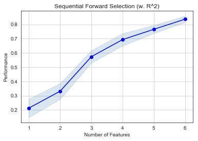

```python
from mlxtend.plotting import plot_sequential_feature_selection as plot_sfs
import matplotlib.pyplot as plt
fig = plot_sfs(sfs1.get_metric_dict())

plt.title('Sequential Forward Selection (w. R^2)')
plt.grid()
plt.show()
```

With this graph we can see that the model performs best when ther are 6 features.

```python
columnList = list(X_train.columns)
feat_cols = list(sfs1.k_feature_idx_)
print(feat_cols)
subsetColumnList = [columnList[i] for i in feat_cols]
print(subsetColumnList)
```

```
[0, 1, 4, 5, 6, 7]
['slag', 'ash', 'coarseagg', 'fineagg', 'age', 'strength']
```

We can see which all features are contributing the most.

```python
linR = LinearRegression()
linR.fit(X_train[subsetColumnList], y_train)
y_train_pred = linR.predict(X_train[subsetColumnList])
print('Training accuracy on selected features: %.3f' % linR.score(X_train[subsetColumnList], y_train))
y_test_pred = linR.predict(X_test[subsetColumnList])
print('Testing accuracy on selected features: %.3f' % linR.score(X_test[subsetColumnList], y_test))
```

```
Training accuracy on selected features: 0.842
Testing accuracy on selected features: 0.827
```

The training accuracy is 84 and test gives 82 for 6 features which is again good for a model.

## Pipeline model

```python
from sklearn.pipeline import Pipeline
pipeline = Pipeline([
    ('scaler',StandardScaler()),
    ('clf', LinearRegression())
])
pipeline.fit(X_train,y_train)
```

```
Pipeline(steps=[('scaler', StandardScaler()), ('clf', LinearRegression())])
```

```python
y_predict = pipeline.predict(X_test)
model_score = pipeline.score(X_test, y_test)
print(model_score)
```

```
0.8863694044280368
```

```python
result= pd.DataFrame({'Model' : ['Linear Regression', 'Ridge', "Lasso","FeatureEngineering", 'Pipeline'],
                    'Accuracy': [  OrigScore*100, ridge1.score(X_poly_test, y_poly_test)*100, lasso.score(X_poly_test, y_poly_test)*100,
                                                   linR.score(X_test[subsetColumnList], y_test)*100,model_score*100]});
result
```

|  | Model | Accuracy |
| --- | --- | --- |
| 0 | Linear Regression | 88.600000 |
| 1 | Ridge | 80.066685 |
| 2 | Lasso | 92.507703 |
| 3 | FeatureEngineering | 82.694424 |
| 4 | Pipeline | 88.636940 |

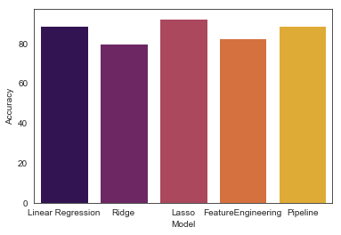

```python
sns.barplot(x=result['Model'],y=result['Accuracy'],data=result,palette='inferno')
```

As we can see here the models can be compared with each other and see which tweaking method has increased the performance of the model and decide whcih is best.

The above graph clearly shows we get more accuracy when Lasso model is applied on the model with Polynomial features. which gives more than 90% accuracy with the rest of the models giving below 90%. Hence Linear regression tweaked by adding Polynomial features and using Lasso to use only the features necessary and contributiong to the model.

### Confidence Interval

```python
print("Linear Regression Model Accuracy: %.3f%% (%.3f%%)" % (results.mean()*100.0, (results.std()*100)*1.96))
```

```
Linear Regression Model Accuracy: 87.622% (11.108%)
```

##### The model will perform at 76% to 98% accuracy fro 95% of the time.